# Practical part of homework 4

## Koosha Jaferian - 95105454

## Question 1:

We want to have a completely uniform distribution on surface of the unit circle.

the first way you might think about is to choose x from -1 to 1 uniformly and then choose y uniformly from
$$[-\sqrt{1-x^2}, \sqrt{1-x^2}]$$

we produce 10000 points with this method. the density of the points will look like this :

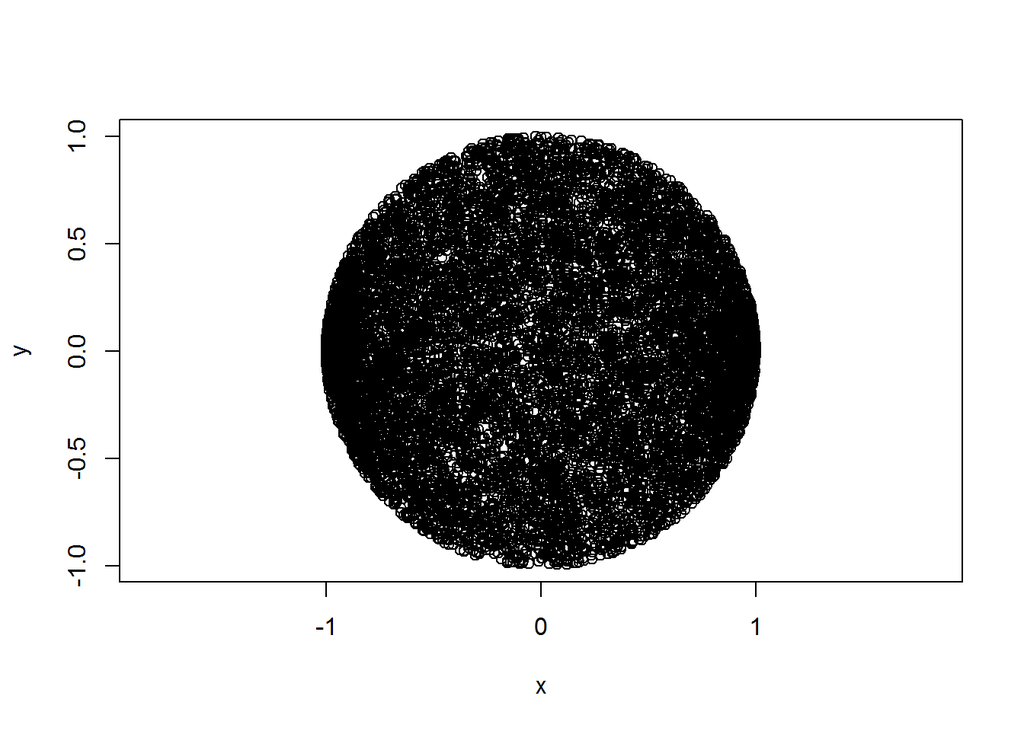

As we see the density of the points on the left and right hand sides is much more than center. so this method is not good for choosing with exactly the same chance!

another method that you might think of is by choosing a radius uniformly from 0 to 1 and then an angle uniformly from
$$[0,2\pi]$$
.

if we do this with 10000 samples the density of the points will look like this:

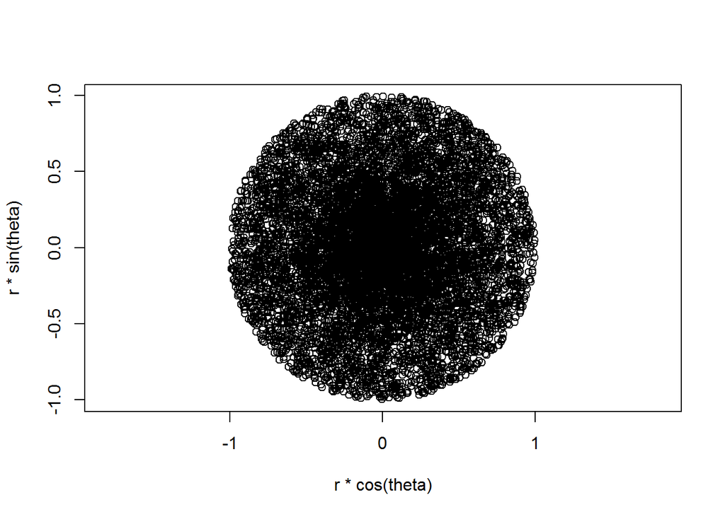

As you clearly see the density near the center is much more than the density far from the center. so this method is not good as well!

the method that gives us the completly uniform choosing from surface of the unit circle is really simillar to the one with angle and radius, but because we want the probability to be related with the area of a part, we substitute r with
$$\sqrt{r}$$
and use the same method again.

the density of the points will look like this:

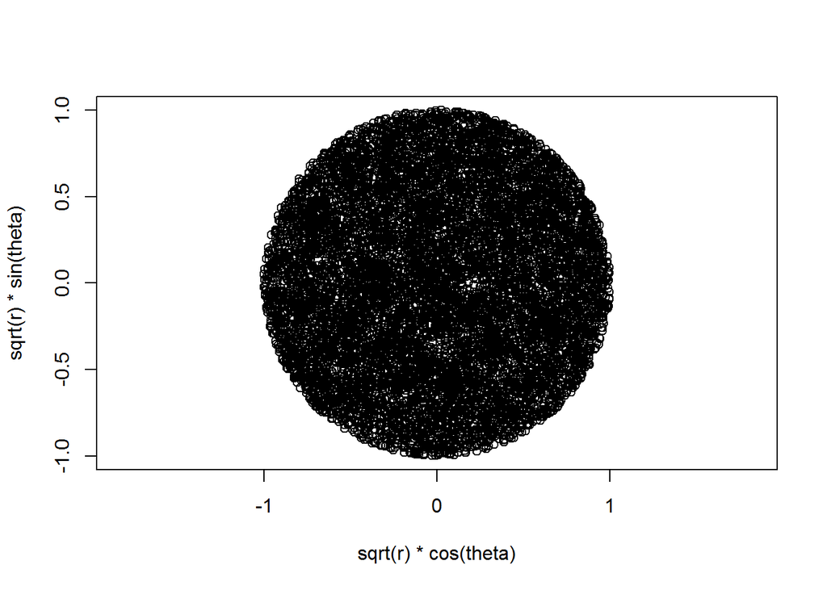

As you see the density of the points in all parts of circle is nearly the same! so this is the best way for uniformly choosing a point from surface of unit circle!

## Question 2 :

In this part we want to check the central limit theorem for n = 50. if
$$Y = \frac{X1+X2+...Xn}{\sqrt{n}}$$
then we will produce 100000 of these (y)s and draw its histogram!

the result will look like this :

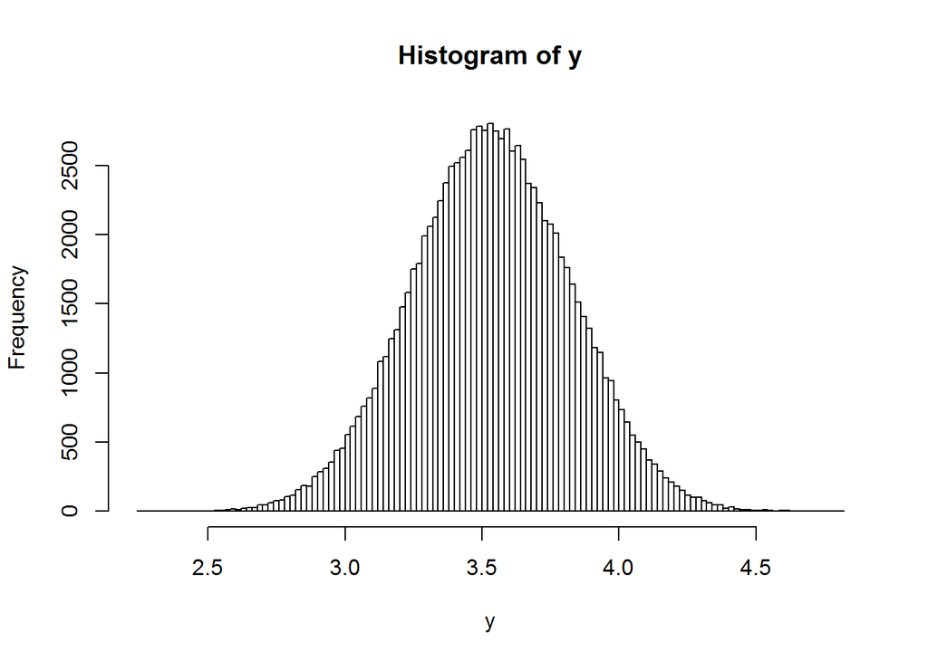

So we can conclude that if we have so many samples, the distribution of y’s will be very close to normal distribution given in the question.